# Reproducible Research: Course Project 1

Jun Yitt, Cheah

March 22, 2017

# Loading and preprocessing the data

```r
suppressMessages(library(dplyr))
suppressWarnings(library(ggplot2))


setwd("C:/Users/User/Desktop")
df <- read.csv("activity.csv", stringsAsFactors = F)
```

# What is mean total number of steps taken per day?

### 1. Calculate the total number of steps taken per day

```r
stepsday <- df %>% group_by(date) %>% summarise(sum = sum(steps, na.rm = T))
stepsday
```

```
## # A tibble: 61 x 2
##          date   sum
##         <chr> <int>
## 1  2012-10-01     0
## 2  2012-10-02   126
## 3  2012-10-03 11352
## 4  2012-10-04 12116
## 5  2012-10-05 13294
## 6  2012-10-06 15420
## 7  2012-10-07 11015
## 8  2012-10-08     0
## 9  2012-10-09 12811
## 10 2012-10-10  9900
## # ... with 51 more rows
```

### 2. Make a histogram of the total number of steps taken each day

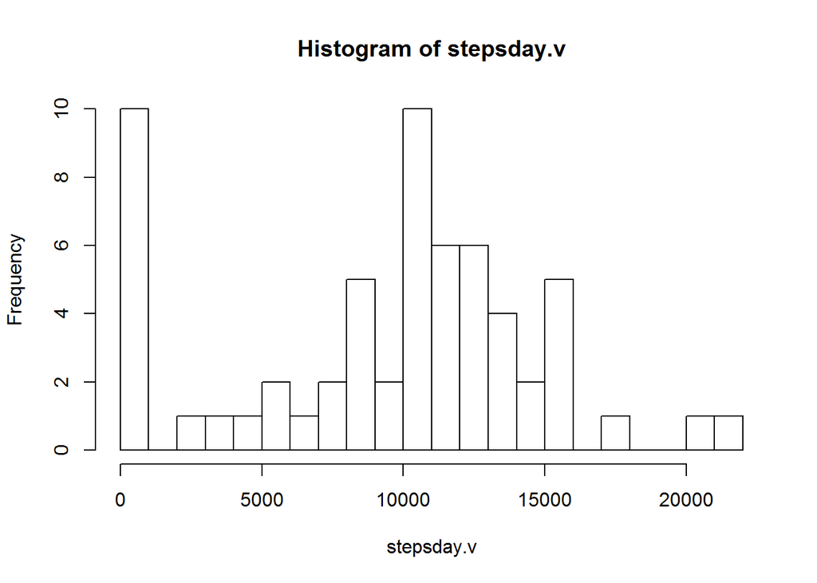

```r
stepsday.v <- as.numeric(as.data.frame(stepsday)[,2])
hist(stepsday.v, breaks = 30)
```

### 3. Calculate and report the mean and median of the total number of steps taken per day

```r
mean1 <- format(mean(stepsday.v) )
median1 <- format(median(stepsday.v))
mean1
```

```
## [1] "9354.23"
```

```r
median1
```

```
## [1] "10395"
```

The mean and median of the total number of steps taken per day are 9354.23 and 10395 respectively.

# What is the average daily activity pattern?

### 1. Make a time series plot (i.e. type = “l”) of the 5-minute interval (x-axis) and the average number of steps taken, averaged across all days (y-axis)

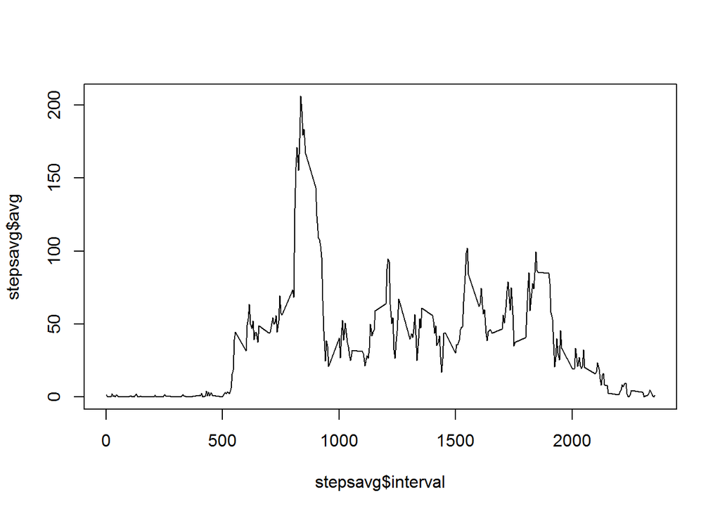

```r
stepsavg <- df %>% group_by(interval) %>% summarise(avg = mean(steps, na.rm = T))
plot(x=stepsavg$interval, y = stepsavg$avg, type = "l")
```

### 2. Which 5-minute interval, on average across all the days in the dataset, contains the maximum number of steps?

```r
maxint <- stepsavg$interval[stepsavg$avg == max(stepsavg$avg)]
maxint
```

```
## [1] 835
```

# Imputing missing values

### 1. Calculate and report the total number of missing values in the dataset (i.e. the total number of rows with NAs)

```r
sumna <- sum(is.na(df$steps))
sumna
```

```
## [1] 2304
```

The total number of missing values in the dataset is 2304.

### 2. Devise a strategy for filling in all of the missing values in the dataset.

First, create a duplicate dataset of the original dataset.  
Then, replace each missing value with the mean of the total number of steps taken in that respective 5-minute interval across the dataset.

```r
df2 <- df

uniqueinterval.v <- unique(df2$interval)
stepsavg.df <- as.data.frame(stepsavg)

for(x in uniqueinterval.v){
      u1 <- is.na(df2$steps)
      u2 <- df2$interval %in% x
      df2[u1&u2, "steps"] <- stepsavg.df[stepsavg.df$interval == x, "avg"]
}
```

### 3. Create a new dataset that is equal to the original dataset but with the missing data filled in.

The new dataset is created.

```r
head(df2)
```

```
##       steps       date interval
## 1 1.7169811 2012-10-01        0
## 2 0.3396226 2012-10-01        5
## 3 0.1320755 2012-10-01       10
## 4 0.1509434 2012-10-01       15
## 5 0.0754717 2012-10-01       20
## 6 2.0943396 2012-10-01       25
```

### 4. Make a histogram of the total number of steps taken each day. Calculate and report the mean and median total number of steps taken per day.

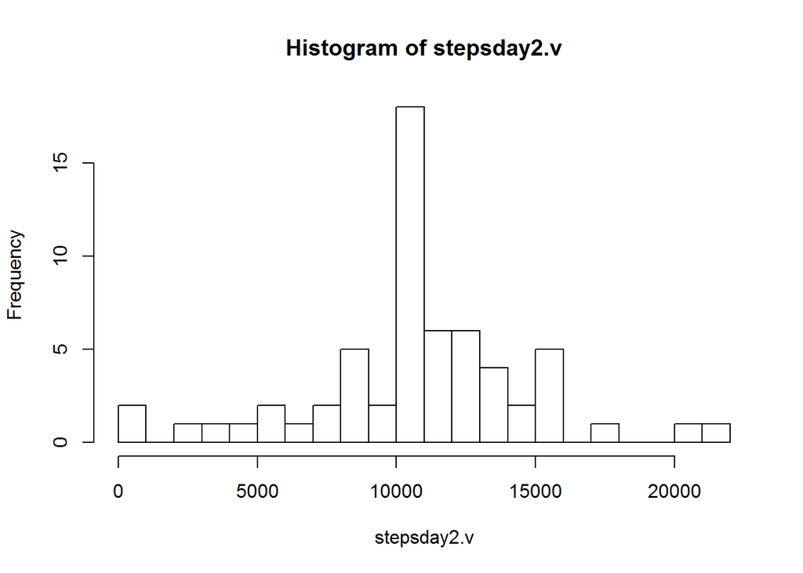

```r
stepsday2 <- df2 %>% group_by(date) %>% summarise(sum = sum(steps, na.rm = T))
stepsday2.v <- as.numeric(as.data.frame(stepsday2)[,2])

hist(stepsday2.v, breaks = 30)
```

```r
mean2 <- format(mean(stepsday2.v))
median2 <- format(median(stepsday2.v))
mean2
```

```
## [1] "10766.19"
```

```r
median2
```

```
## [1] "10766.19"
```

The new mean and median of the total number of steps taken per day are 10766.19 and 10766.19 respectively. The new mean and median is slightly higher than the mean and median computed earlier (9354.23 and 10395 respectively). Hence, the estimates might be higher using the new dataset.

# Are there differences in activity patterns between weekdays and weekends?

### 1. Creating a factor variable to distinguish weekday and weekend

```r
df3 <- df2 %>% mutate(day1 = weekdays(as.Date(date)), wd = weekdays(as.Date(date)) %in% c("Saturday", "Sunday") )  %>% mutate(factorwk = factor(wd, c(FALSE, TRUE), labels = c("weekday", "weekend")))

head(df3)
```

```
##       steps       date interval   day1    wd factorwk
## 1 1.7169811 2012-10-01        0 Monday FALSE  weekday
## 2 0.3396226 2012-10-01        5 Monday FALSE  weekday
## 3 0.1320755 2012-10-01       10 Monday FALSE  weekday
## 4 0.1509434 2012-10-01       15 Monday FALSE  weekday
## 5 0.0754717 2012-10-01       20 Monday FALSE  weekday
## 6 2.0943396 2012-10-01       25 Monday FALSE  weekday
```

```r
tail(df3)
```

```
##           steps       date interval   day1    wd factorwk
## 17563 2.6037736 2012-11-30     2330 Friday FALSE  weekday
## 17564 4.6981132 2012-11-30     2335 Friday FALSE  weekday
## 17565 3.3018868 2012-11-30     2340 Friday FALSE  weekday
## 17566 0.6415094 2012-11-30     2345 Friday FALSE  weekday
## 17567 0.2264151 2012-11-30     2350 Friday FALSE  weekday
## 17568 1.0754717 2012-11-30     2355 Friday FALSE  weekday
```

### 2. Make a panel plot containing a time series plot (i.e. type = “l”) of the 5-minute interval (x-axis) and the average number of steps taken, averaged across all weekday days or weekend days (y-axis)

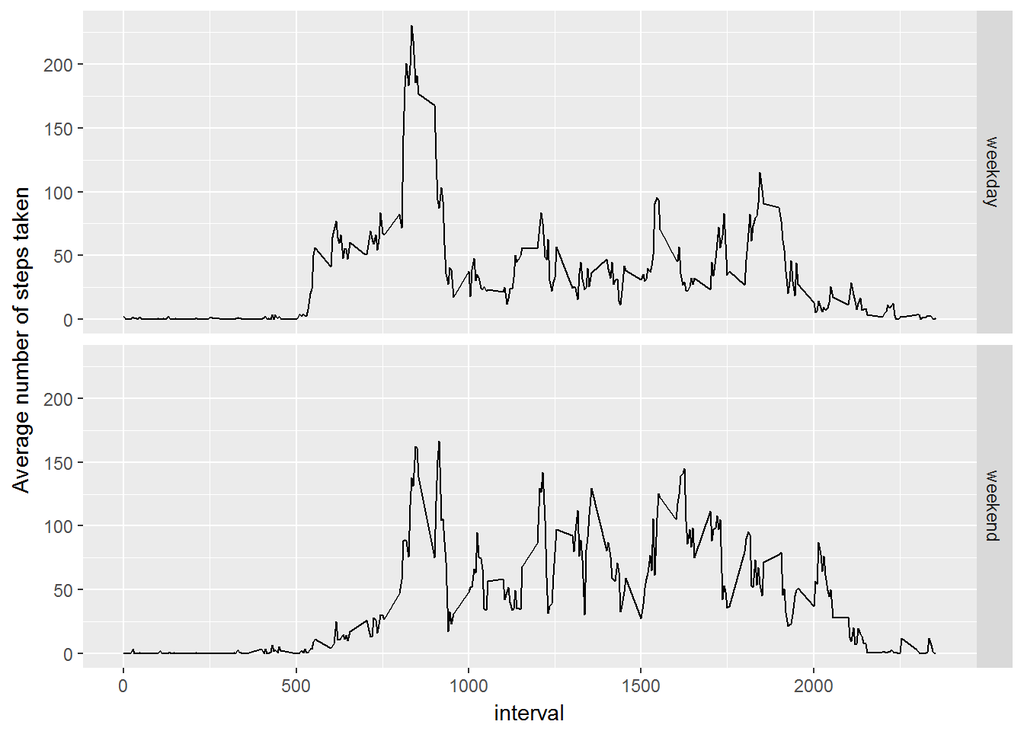

```r
df4 <- df3 %>% group_by(factorwk, interval) %>% summarise(msteps = mean(steps))

ggplot(data = df4, mapping = aes(x = interval, y = msteps)) + geom_line() + facet_grid(factorwk~.) + ylab("Average number of steps taken")
```